# W6: Practicing functions

Mie Arnau Martinez

10/22/2020

Hint: If you are struggling with the gapminder tibble format, consider converting it into a dataframe (from tibble), either by downloading it from the internet and loading it via read.csv (not read_csv), and/or using as.data.frame() conversion function and then appropriately subsetting.

1. Define a defensive function that calculates the Gross Domestic Product of a nation from the data available in the gapminder dataset. Using that function, calculate the GDP of Denmark in the following years: 1967, 1977, 1987, 1997, 2007, and 2017.

```r
# Function to calculate Gross Domestic Product of any nation
# The function takes a dataframe and can also take a country and year
gdp <- function(df, country = NULL, year = NULL){
  # The first if statement is used to subset the dataframe is a country (or countries) are specified. This will make the rest of the function only use the data that contains information specific to that country.
   if(!is.null(country)){
    # To make the function defensive, I add a function that checks up on the parameters country and year.
    # Here country should be a character or a list of characters.
    stopifnot(is.character(country))
    df <- df[df$country %in% country, ]
   }
  # The second if statement is similar to the first but regards a specified year (or list of years)
  if(!is.null(year)){
    # Same as in the first if statement but here year should be a numeric value.
    stopifnot(is.numeric(year))
    # The %in% makes the function flexible so that it can take in more than one value.
    df <- df[df$year %in% year, ]
  }
 # Then the gdp is calculated and stored in the object result
  result <- df$pop * df$gdpPercap
  # To make sense of the output, the result is combined with the dataframe to make a new dataframe that holds all information
  new_df <- cbind(df, gdp = result)
  # This is then returned at the end of the function
  return(new_df)
}

# Then a list is made to contain the years we want to look at
years = c(1967, 1977, 1987, 1997, 2007, 2017)
# The country and years are then feed to the function alongside the dataframe
gdp(gapminder, country = "Denmark", year = years)
```

```
##     country continent year lifeExp     pop gdpPercap          gdp
## 412 Denmark    Europe 1967  72.960 4838800  15937.21  77116977700
## 414 Denmark    Europe 1977  74.690 5088419  20422.90 103920280028
## 416 Denmark    Europe 1987  74.800 5127024  25116.18 128771236166
## 418 Denmark    Europe 1997  76.110 5283663  29804.35 157476118456
## 420 Denmark    Europe 2007  78.332 5468120  35278.42 192906627081
```

From the function, we get the Gross Domestic Product in Denmark in the years 1967, 1977, 1987, 1997 and 2007 as can be read from the table above.

2. Write a script that loops over each country in the gapminder dataset, tests whether the country starts with a ‘B’ , and print out whether the life expectancy is smaller than 50, between 50 and 70, or greater than 70.

```r
# For the first task, this line of code will detect unique countries starting with the letter B (or b for flexibility) and then assign these to the object b_country
b_country <- grep("^[Bb].", unique(gapminder$country), value = TRUE)
# I then define the thresholds for the lower and upper life expectancy
lowerthres <- 50
upperthres <- 70

# Then I make a for loop that loops through the list of countries starting with "B".
for (i in b_country){
  # As there are more than one row for each country, I calculate the average life expectancy across years for the countries starting with b using the mean() function and subsetting the data to only contain one country. This is done by using the "i" as this tells the computer to only calculate the mean life expectancy for the country that the loop has gotten to in the list b_country. All this is held in a temporary dataframe (tmp)
  tmp <- mean(gapminder[gapminder$country == i, "lifeExp"])
  # Then, I start an if statement that first looks at whether the average life expectancy is below the lower threshold (50). If the condition is true, it prints "Average Life Expectancy in 'country' is less than 50". If the condition is wrong, the script will just continue to the next condition.
  if (tmp < lowerthres){
    cat("Average Life Expectancy in", i, "is less than", lowerthres, "\n")
    # For this to be true the average life expectancy has to be greater than 50 and lower than 70.
  } else if (lowerthres < tmp && tmp < upperthres){
    cat("Average Life Expectancy in", i, "is between", lowerthres, "and", upperthres, "\n")
    # For this to be true, tmp has to be greater than 70.
  } else if (tmp > upperthres){
    cat("Average Life Expectancy in", i, "is greater than", upperthres, "\n")
  }
}
```

```
## Average Life Expectancy in Bahrain is between 50 and 70
## Average Life Expectancy in Bangladesh is less than 50
## Average Life Expectancy in Belgium is greater than 70
## Average Life Expectancy in Benin is less than 50
## Average Life Expectancy in Bolivia is between 50 and 70
## Average Life Expectancy in Bosnia and Herzegovina is between 50 and 70
## Average Life Expectancy in Botswana is between 50 and 70
## Average Life Expectancy in Brazil is between 50 and 70
## Average Life Expectancy in Bulgaria is between 50 and 70
## Average Life Expectancy in Burkina Faso is less than 50
## Average Life Expectancy in Burundi is less than 50
```

As can be seen, the script prints out the statements for each of the countries starting with the letter “B”.

3. Optional: Write a script that loops over each country in the gapminder dataset, tests whether the country starts with a ‘M’ and graphs life expectancy against time (using plot() function) as a line graph if the mean life expectancy is under 50 years.

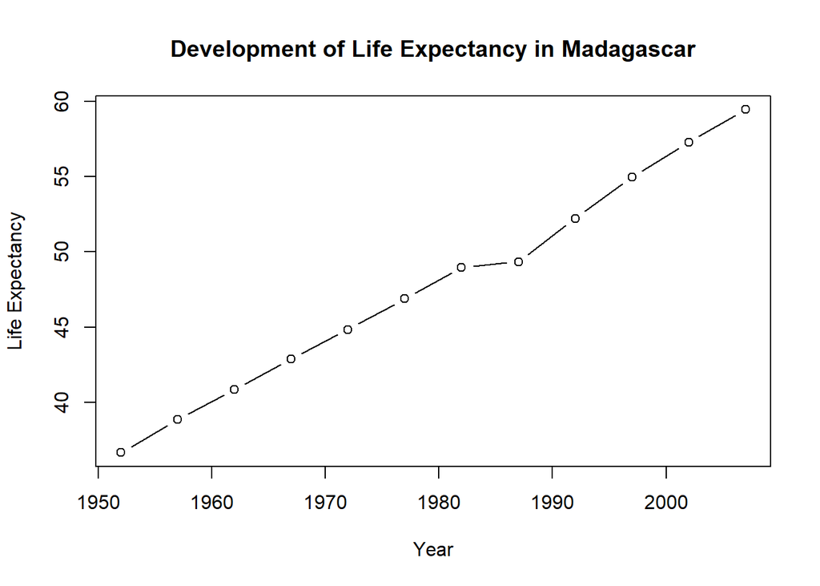

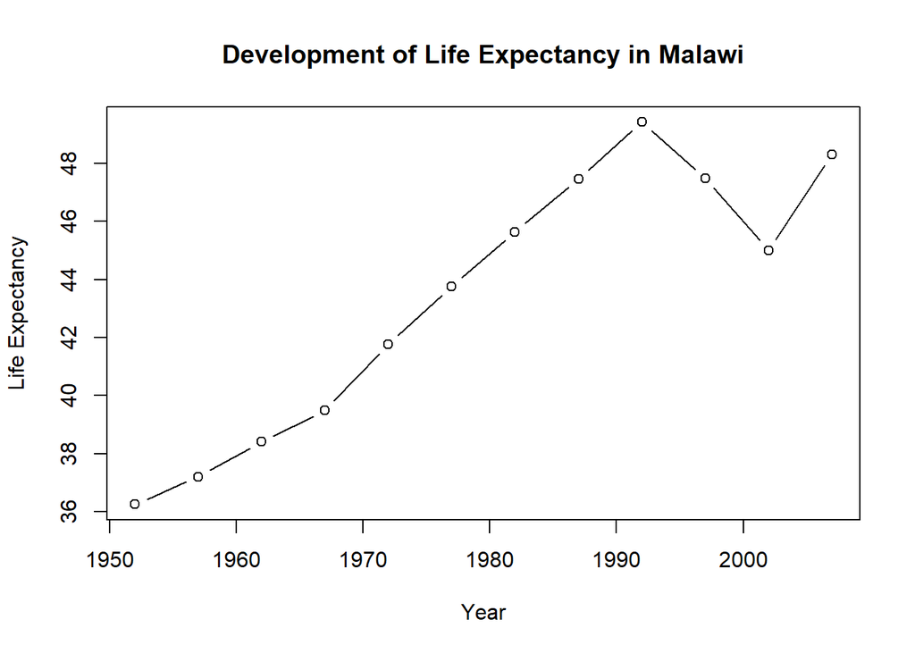

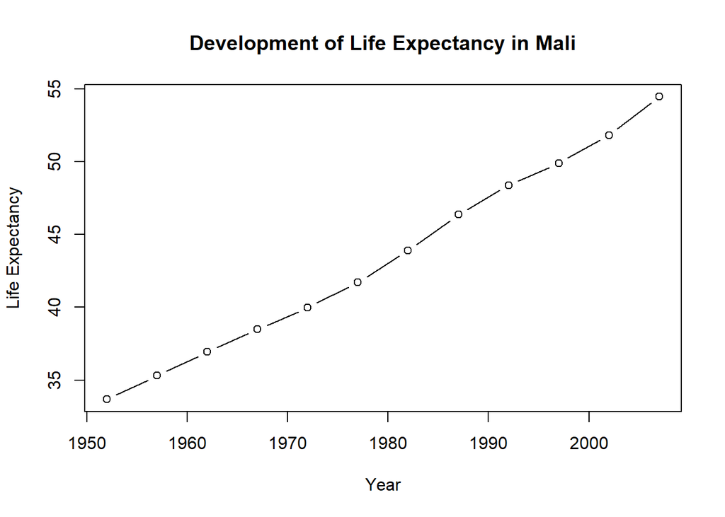

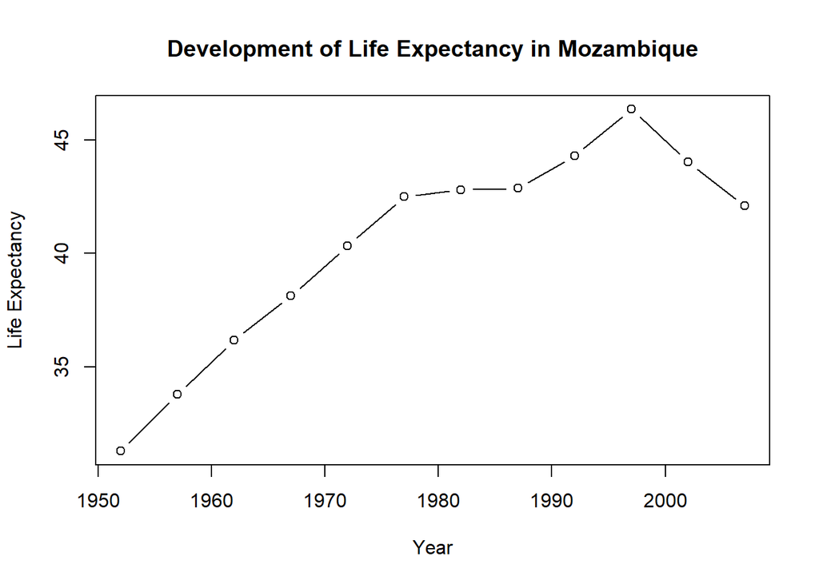

```r
# Defining a new object that holds unique countries that starts with "M" (or m for flexibility).
m_countries <- grep("^[Mm].", unique(gapminder$country), value=TRUE)

for (i in m_countries) {
  # Like before we calculate the mean life expectancy
    tmp <- mean(gapminder[gapminder$country == i, "lifeExp"])
    # then we check if it is under 50 years and if it is we plot the life expectancy against time
    if(tmp < lowerthres){
      # Subsetting the data to only hold the specific country
          with(subset(gapminder, country==i),
               # plotting the life expectancy against year
                plot(year, lifeExp,
                     # Plotting both points and lines
                     type = "b",
                     # Making a main title by pasting strings and the value of i
                     main = paste("Development of Life Expectancy in", i),
                     # Label for the x axis
                     ylab = "Life Expectancy",
                     # Label for the y axis
                     xlab = "Year"
                   )
              )
    }
 }
```

So, we get four plots for the development of life expectancy in Madagascar, Malawi, Mali and Mozambique.